# Lab 7: Nonlinearity and Resampling

The purpose of this lab is to get experience for modelling nonlinear relationship and data resampling techniques.

**It is strongly recommended that you complete this lab on the VMs, but it can also be completed on any computer that has R (version >= 4.0) available. Your final R markdown document must be processed on the VMs to produce the HTML document for submission.**

# The Data Set

We are going to the use a subset of the `automobile` data set that was used in Lab 6. In particular, the variables `wheel.base`, `length`, `height`, `highway.mpg` and `price` are considered in this lab. To concentrate, we can produce a subset data frame `auto2` as follows:

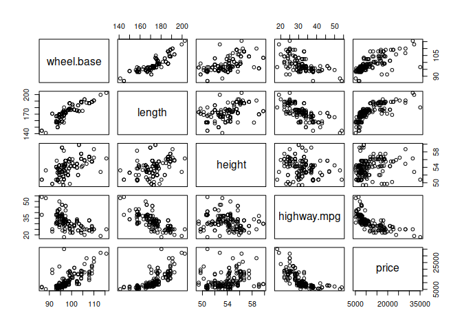

```r
auto = read.csv("automobile.csv", stringsAsFactors=TRUE)
auto2 = auto[,c("wheel.base", "length", "height", "highway.mpg", "price")]
pairs(auto2)
```

Variable `price` will remain to be the response variable in the following studies.

# Tasks

Make sure you have loaded the following libraries:

```r
library(splines)
library(gam)
library(parallel)
```

## Modelling Nonlinear Relationship

Consider polynomial regression models using `highway.mpg` to predict the value of `price`.

1. Find all polynomial regression models for degrees 1 to 5.
2. Superimpose them all in one scatter plot of the data.

   What do you generally observe in the fitted curve when the polynomial degree increases?
3. Find the BIC-selected polynomial regression model. (You may consider using the residuals provided by the `lm()` fit`.)

   Do you think this is a reasonable fit?

   (Note: Model selection criteria may become fairly unreliable for high-degree polynomials.)

## Generalised Additive Models

4. Fit a GAM to the data set, using a smoothing spline with 5 degrees of freedom for each predictor variable: `wheel.base`, `length`, `height`, `highway.mpg`.

   Create the plots for all the additive terms in the model.
5. Use your GAM to predict the `price` value for a new observation: `wheel.base = 110`, `length = 190`, `height = 55`, `highway.mpg = 25`.
6. Re-fit your GAM by adjusting manually the degrees of freedom of smoothing splines used for the additive terms until the fit **visually** looks reasonable to you. Provide some arguments.

## Cross-validation for Regression Splines

7. For cubic regression splines, let us consider using knots that are evenly distributed between the two extreme values (minimum and maximum) of the predictor variable, but excluding the two extreme values. That is, given the number of knots, `m`, we create the knots as follow:

   ```r
   attach(auto2)
   m = 5            # number of knots
   (rg = range(highway.mpg))
   ```

   ```
   [1] 18 54
   ```

   ```r
   (knots = seq(rg[1], rg[2], length=m+2)[-c(1,m+2)])
   ```

   ```
   [1] 24 30 36 42 48
   ```

   ```r
   detach(auto2)
   ```

   Find this cubic regression spline fit (with `m = 5`) to the data (`price` vs. `highway.mpg`) and show it in a scatter plot of the two variables.
8. Use $10$-fold cross-validation to find an appropriate value for `m`. Consider `m = 1, 2, ..., 5` in your CV study. Explain why you have used the technique of same subsamples.

   Note that the knots should be chosen based on the extreme values of each training set.
9. Find your final model and show it in a scatter plot of the two variables.

## Jackknifing and Parallel Computing

10. Use the Jackknifing technique (with a 90% for training and 10% for testing) to find an appropriate degree for polynomial regression as in Tasks 1-3. Use `R = 200` as the number of repetitions.

    Show the curve of the selected model in a scatter plot of the data.
11. Rewrite/reorganise your code so that each repetition can be carried out independently. Perform the Jackknifing selection of the polynomial degree using parallel computing, with function `mclapply()`.

    Compare the timings, when 1, 5, 10 or 20 cores are used (so you have to do this on a VM).
12. For results to be reproducible, it is better to use random seeds. Investigate and demonstrate how this can be achieved when `mclapply()` is used.

    [Not as part of this assignment, you might want to consider how parallel computing can be used for cross-validation.]

# The Report

Your submission should consist of an R Markdown document, submitted via Canvas. You should write your document so that I can process it on my computer without any manual intervention. For example, do not include any calls to `setwd()` or `file.choose()`. You should write code that assumes that data ﬁles are in the current working directory or at a fixed location on the VMs. Also submit a processed version of your R Markdown document (an HTML document) in case I cannot process your document on my computer.

Your report should include:

- A brief description of the data.
- For each task, R code AND a brief text commentary.
- A summary of the entire report.

# Marking

Marks will be lost for:

- R Markdown ﬁle is missing.
- R Markdown ﬁle does not run.
- Processed ﬁle (HTML) is missing.
- Section of the report is missing.
- Unintelligible, or confusing, or irrelevant summary.
- Signiﬁcantly poor R (or other) code.
- Overly verbose code, output, or commentary.

This work is licensed under a [Creative Commons Attribution 4.0 International License](http://creativecommons.org/licenses/by/4.0/).